# Monitoramento Blend4

## Execução

```
Última execução: 13/11/2026 11:25:04 -03
```

## Imports

## Diretório

## Base Blend4 em Produção

## Gráficos

# Uniproponente

# Primeira Semana

Acompanhamento diário do Mix de Modelos que vemos dos nossos leads.

```
Período: 2026-11-05 00:00:00 → 2026-11-12 00:00:00
Volume total: 37,479
```

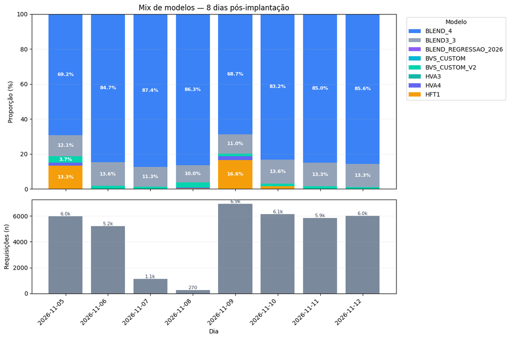

## Semanal

```
Semanas: 6 | Volume: 165,297
Período: 2026-10-04 00:00:00 → 2026-11-12 00:00:00
```

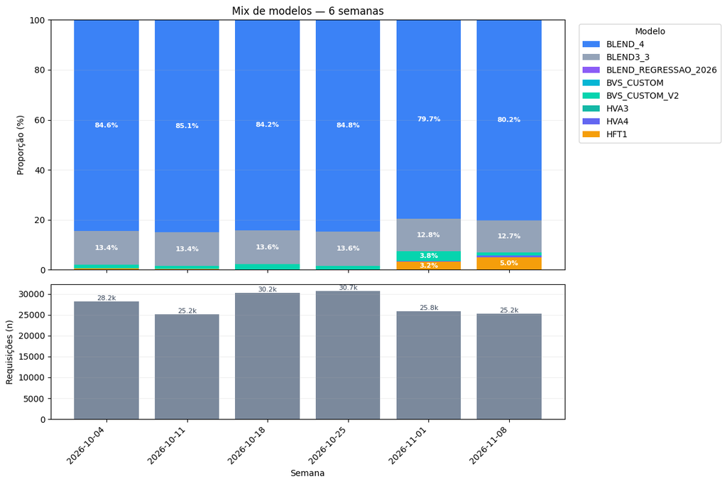

## Mix de Rating BLEND4 vs. BLEND3

Esse Mix de Rating não é exatamente o Mix de Rating visto na tabela do Funil, pois estamos avaliando o público que tem score Blend4, ou seja excluindo o público E-BVS, negado diretamente.

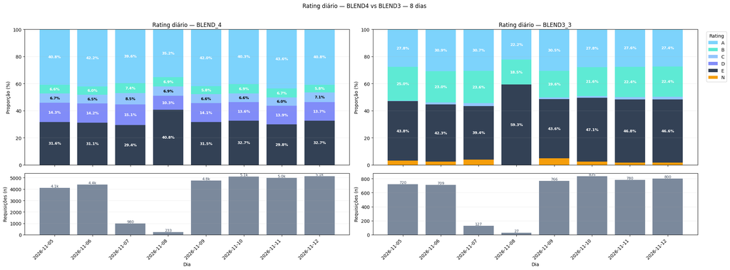

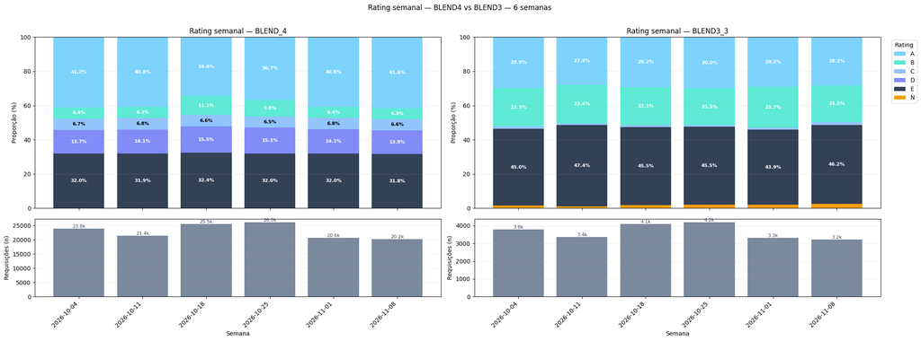

# Comparação: Score CR vs. Score Manual

Nessa secção queremos entender se não há nenhum erro de escoragem no Modelo BLEND4, ou seja, se score que está na CR é o mesmo que o escorado manualmente.

## Scores Blend4

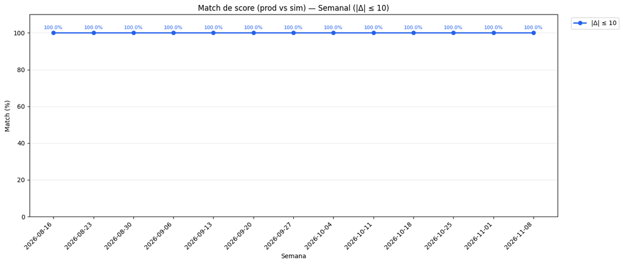

## Ratings

No caos dos Ratings, o que queremos é entender se em dias que houve alguma falha de escoragem, se houve alteração no Mix.

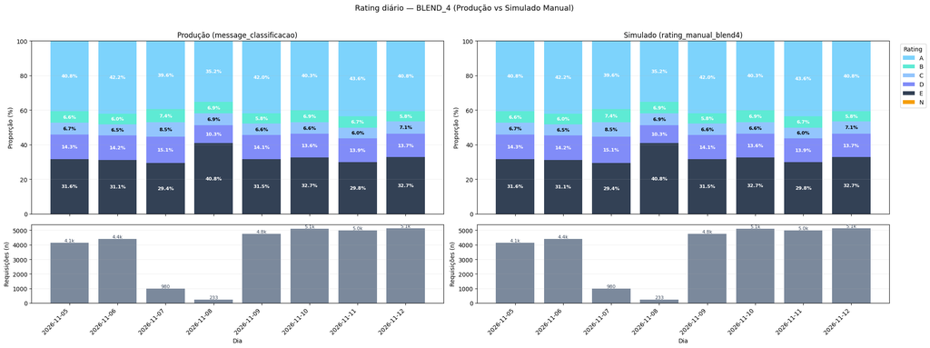

```
BLEND_4
```

| rating_manual_blend4 message_classificacao | A | B | C | D | E | All |
| --- | --- | --- | --- | --- | --- | --- |
| A | 12334 | 0 | 0 | 0 | 0 | 12334 |
| B | 0 | 1886 | 0 | 0 | 0 | 1886 |
| C | 0 | 0 | 1972 | 0 | 0 | 1972 |
| D | 0 | 0 | 0 | 4142 | 0 | 4142 |
| E | 0 | 0 | 0 | 0 | 9384 | 9384 |
| All | 12334 | 1886 | 1972 | 4142 | 9384 | 29718 |

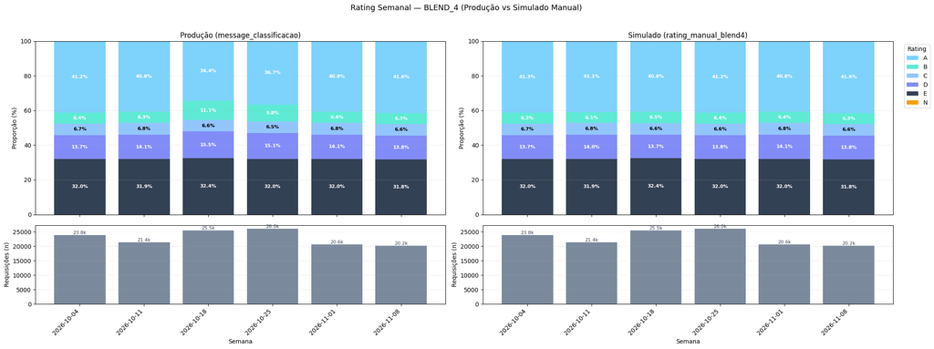

```
BLEND_4
```

| rating_manual_blend4 message_classificacao | A | B | C | D | E | All |
| --- | --- | --- | --- | --- | --- | --- |
| A | 53668 | 0 | 0 | 0 | 0 | 53668 |
| B | 2889 | 7945 | 0 | 0 | 0 | 10834 |
| C | 0 | 762 | 8380 | 0 | 0 | 9142 |
| D | 0 | 0 | 798 | 19022 | 0 | 19820 |
| E | 0 | 0 | 0 | 0 | 44033 | 44033 |
| All | 56557 | 8707 | 9178 | 19022 | 44033 | 137497 |

```
4525
```

[output not shown]

[output cut: 197 more lines]

[output not shown]

|  | contract_id | requested_at | message_classificacao | rating_manual_blend4 | rating_json_blend4 | rating_cl_pol_blend4 | message_blendRegressaoPredict | pred_blend4_1_to_score |
| --- | --- | --- | --- | --- | --- | --- | --- | --- |
| 29360 | 4841590 | 2026-10-22 | B | A | A | 7.B | 509.0 | 509.0 |
| 29361 | 4841601 | 2026-10-22 | B | A | A | 6.B | 541.0 | 541.0 |
| 29362 | 4841607 | 2026-10-22 | B | A | A | 4.B+ | 626.0 | 626.0 |
| 29363 | 4841608 | 2026-10-22 | B | A | A | 5.B+ | 578.0 | 578.0 |
| 29367 | 4841633 | 2026-10-22 | B | A | A | 4.B+ | 647.0 | 647.0 |
| ... | ... | ... | ... | ... | ... | ... | ... | ... |
| 391060 | 4857556 | 2026-10-26 | B | A | A | 6.B | 559.0 | 559.0 |
| 391071 | 4857676 | 2026-10-26 | B | A | A | 4.B+ | 647.0 | 647.0 |
| 391072 | 4857679 | 2026-10-26 | B | A | A | 5.B+ | 566.0 | 566.0 |
| 391075 | 4857710 | 2026-10-26 | B | A | A | 4.B+ | 618.0 | 618.0 |
| 391078 | 4857733 | 2026-10-26 | B | A | A | 6.B | 528.0 | 528.0 |

4449 rows × 8 columns

[output not shown]

0 rows × 252 columns

|  | CPF_CNPJ | contract_id | requested_at | data_ultima_consulta | qtd_proponentes | codigo_cidade_ibge | score_imobiliaria | model | id_consulta | id_funcionalidade | ... | pred_blend4_1 | pred_blend4_1_to_score | rating_manual_blend4 | rating_json_blend4 | rating_cl_pol_blend4 | safra | week_start | year_week | year | week_of_year |
| --- | --- | --- | --- | --- | --- | --- | --- | --- | --- | --- | --- | --- | --- | --- | --- | --- | --- | --- | --- | --- | --- |
| 35361 | 6195841650 | 4902422 | 2026-11-05 | 2026-11-05 | 1 | 3152501.0 | A | HFT1 | 6751440 | 33 | ... | 0.570656 | 429.0 | C | NaN | 9.D+ | 2026-11-01 | 2026-11-01 | 2026-11-01 | 2026 | 45 |
| 35362 | 16620391745 | 4902421 | 2026-11-05 | 2026-11-05 | 1 | 4125506.0 | A | HVA4 | 6751441 | 33 | ... | 0.563807 | 436.0 | C | NaN | 9.D+ | 2026-11-01 | 2026-11-01 | 2026-11-01 | 2026 | 45 |
| 35363 | 4327327999 | 4902428 | 2026-11-05 | 2026-11-05 | 1 | 4302105.0 | D | HFT1 | 6751447 | 33 | ... | 0.678701 | 321.0 | E | NaN | E-1.E | 2026-11-01 | 2026-11-01 | 2026-11-01 | 2026 | 45 |
| 35364 | 70431671168 | 4902434 | 2026-11-05 | 2026-11-05 | 1 | 5208707.0 | E | HFT1 | 6751454 | 33 | ... | 0.732894 | 267.0 | E | NaN | E-2.E | 2026-11-01 | 2026-11-01 | 2026-11-01 | 2026 | 45 |
| 35366 | 46562573890 | 4902443 | 2026-11-05 | 2026-11-05 | 1 | 3541406.0 | NI | HVA4 | 6751464 | 33 | ... | 0.647339 | 353.0 | D | NaN | 11.D | 2026-11-01 | 2026-11-01 | 2026-11-01 | 2026 | 45 |
| ... | ... | ... | ... | ... | ... | ... | ... | ... | ... | ... | ... | ... | ... | ... | ... | ... | ... | ... | ... | ... | ... |
| 399262 | 31145614892 | 4904842 | 2026-11-05 | 2026-11-11 | 1 | 3538709.0 | E | BLEND_4 | 6797156 | 31 | ... | 0.343832 | 656.0 | A | A | 3.A | 2026-11-01 | 2026-11-01 | 2026-11-01 | 2026 | 45 |
| 399420 | 11721878432 | 4908694 | 2026-11-05 | 2026-11-12 | 1 | 4302105.0 | NI | BLEND_4 | 6799045 | 36 | ... | 0.616756 | 383.0 | D | D | 10.D | 2026-11-01 | 2026-11-01 | 2026-11-01 | 2026 | 45 |
| 399747 | 29598271803 | 4909009 | 2026-11-05 | 2026-11-12 | 1 | 4313409.0 | B | BLEND3_4 | 6803105 | 32 | ... | 0.751817 | 248.0 | E | E | E-2.E | 2026-11-01 | 2026-11-01 | 2026-11-01 | 2026 | 45 |
| 399894 | 7951588660 | 4908468 | 2026-11-05 | 2026-11-12 | 1 | 3106200.0 | NI | BLEND_4 | 6804951 | 31 | ... | 0.364899 | 635.0 | A | A | 4.B+ | 2026-11-01 | 2026-11-01 | 2026-11-01 | 2026 | 45 |
| 399943 | 47952894846 | 4906937 | 2026-11-05 | 2026-11-12 | 1 | 3547809.0 | D | BLEND_4 | 6805485 | 36 | ... | 0.632483 | 368.0 | D | D | 11.D | 2026-11-01 | 2026-11-01 | 2026-11-01 | 2026 | 45 |

5961 rows × 252 columns

```
requested_at
2026-10-05       7
2026-10-06       6
2026-10-07       7
2026-10-08       9
2026-10-09       5
2026-10-10       1
2026-10-13      20
2026-10-14      13
2026-10-15      17
2026-10-16      22
2026-10-17       6
2026-10-18       1
2026-10-19      31
2026-10-20      54
2026-10-21      59
2026-10-22     511
2026-10-23    1559
2026-10-24     318
2026-10-25      35
2026-10-26    1768
dtype: int64
```

## PSI das Variáveis

```
Target day: 2026-11-12
```

|  | variable | comparison | psi | status | n_actual | psi_oot_vs_train_ref | psi_test_vs_train_ref |
| --- | --- | --- | --- | --- | --- | --- | --- |
| 0 | city_pc4_mais_100_contratos__pc_categorias | production_vs_train | 0.140091 | moderate | 5140 | 0.054503 | 0.000085 |
| 1 | income_commitment | production_vs_train | 0.056700 | stable | 5140 | 0.000865 | 0.000048 |
| 2 | SERASA_CHSV5 | production_vs_train | 0.029542 | stable | 5140 | 0.020552 | 0.000130 |
| 3 | pred_blend4_1_to_score | production_vs_train | 0.018592 | stable | 5140 | 0.023760 | 0.000040 |
| 4 | score_proposto__bvs | production_vs_train | 0.011821 | stable | 5140 | 0.010233 | 0.000116 |
| 5 | qtde_restricoes__consulta_realizada | production_vs_train | 0.008443 | stable | 5140 | 0.023589 | 0.000028 |
| 6 | flag_tem__contratos_anteriores | production_vs_train | 0.002957 | stable | 5140 | 0.000000 | 0.000002 |
| 7 | agency_pc4_mais_100_contratos__pc_categorias_i... | production_vs_train | 0.002394 | stable | 5140 | 0.001303 | 0.000000 |
| 8 | flag_teve_boleto_atrasado__contratos_anteriores | production_vs_train | 0.002268 | stable | 5140 | 0.000237 | 0.000002 |
| 9 | property_type | production_vs_train | 0.001782 | stable | 5140 | 0.002975 | 0.000004 |
| 10 | age | production_vs_train | 0.001772 | stable | 5140 | 0.001148 | 0.000071 |
| 11 | agency_pc4_mais_100_contratos__pc_categorias | production_vs_train | 0.001473 | stable | 5140 | 0.005090 | 0.000026 |
| 12 | city_pc4_mais_100_contratos__pc_categorias_is_... | production_vs_train | 0.000712 | stable | 5140 | 0.000236 | 0.000011 |

```
Target Week == 2026-11-01 (Semana Anterior Completa)
```

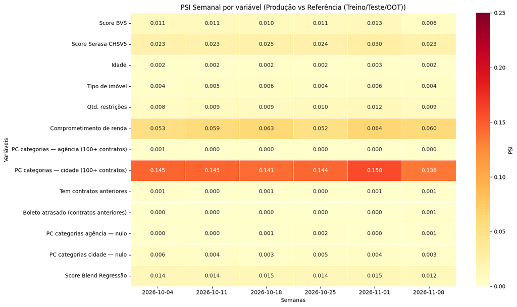

## PSI Semanal W-1 (Última Semana Completa)

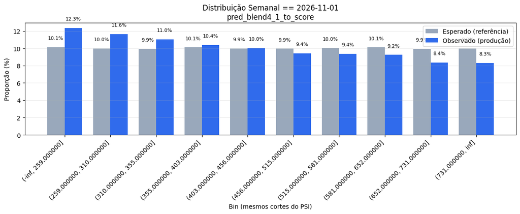

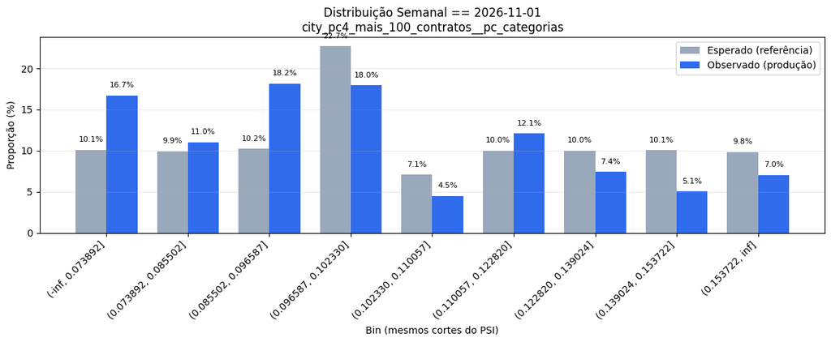

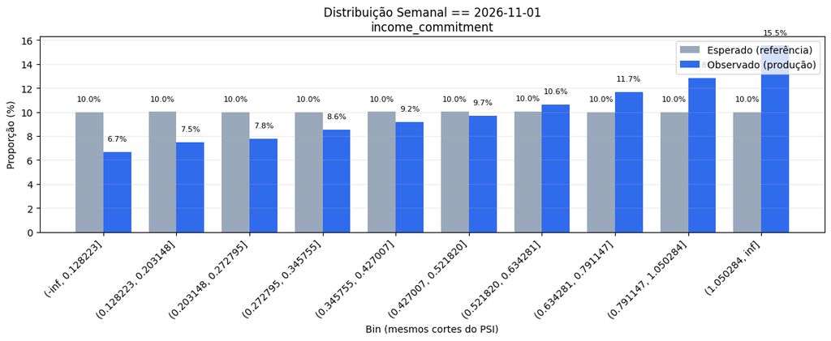

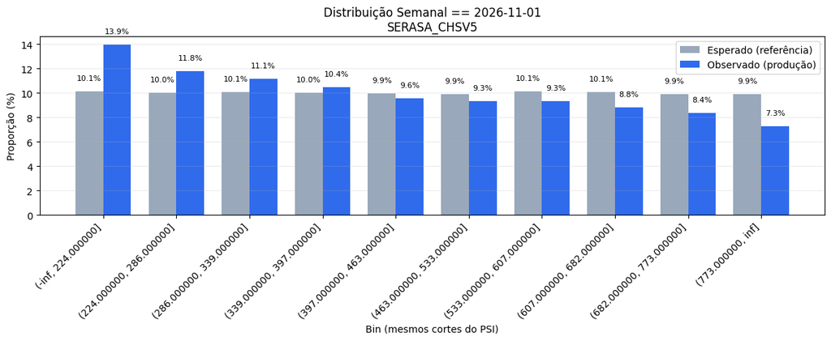

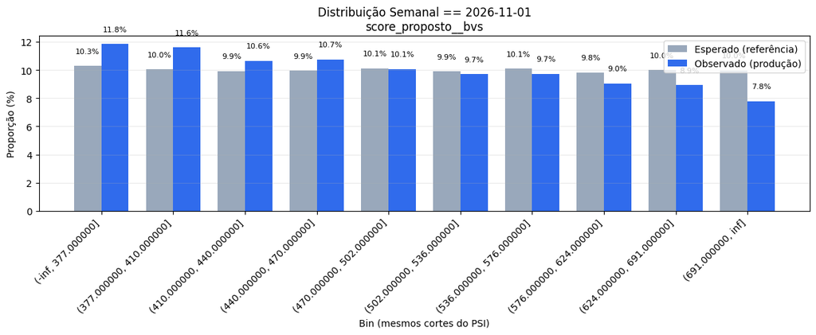

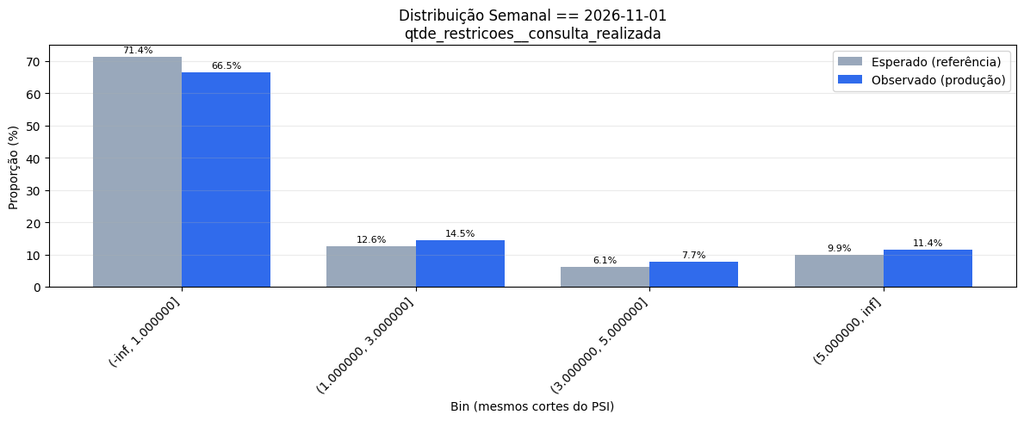

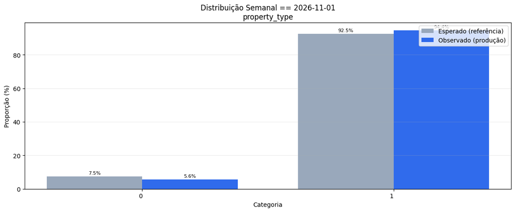

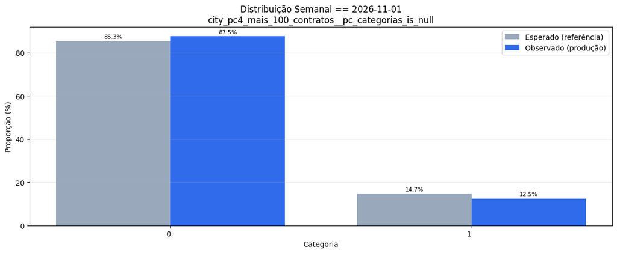

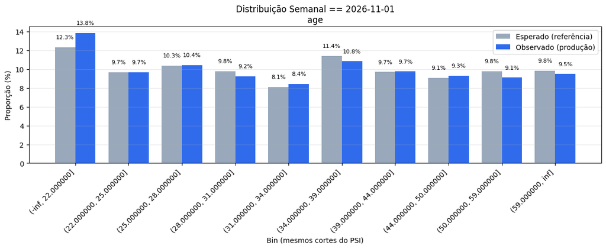

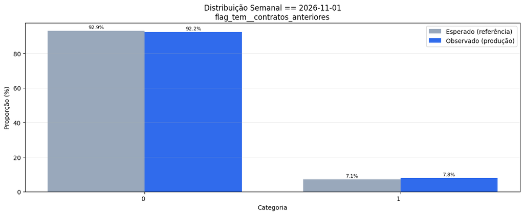

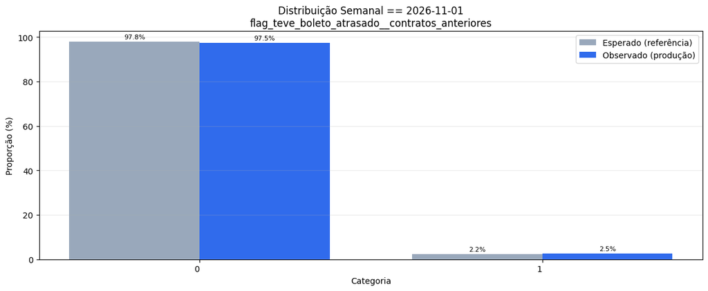

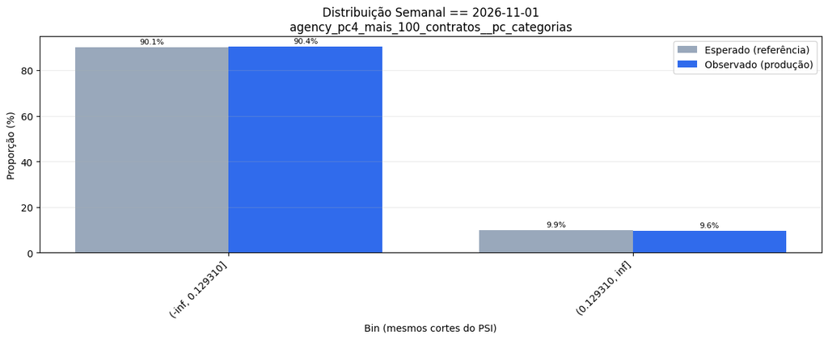

[1 more figures not shown]

# Variáveis: Acompanhamento Histórico

```
Semanas completas: ['2026-10-04', '2026-10-11', '2026-10-18', '2026-10-25', '2026-11-01']
```

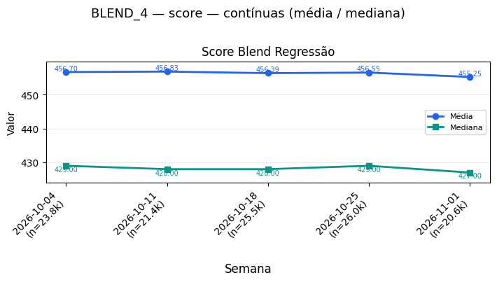

```
[skip] Sem estatísticas binárias para plotar.
```

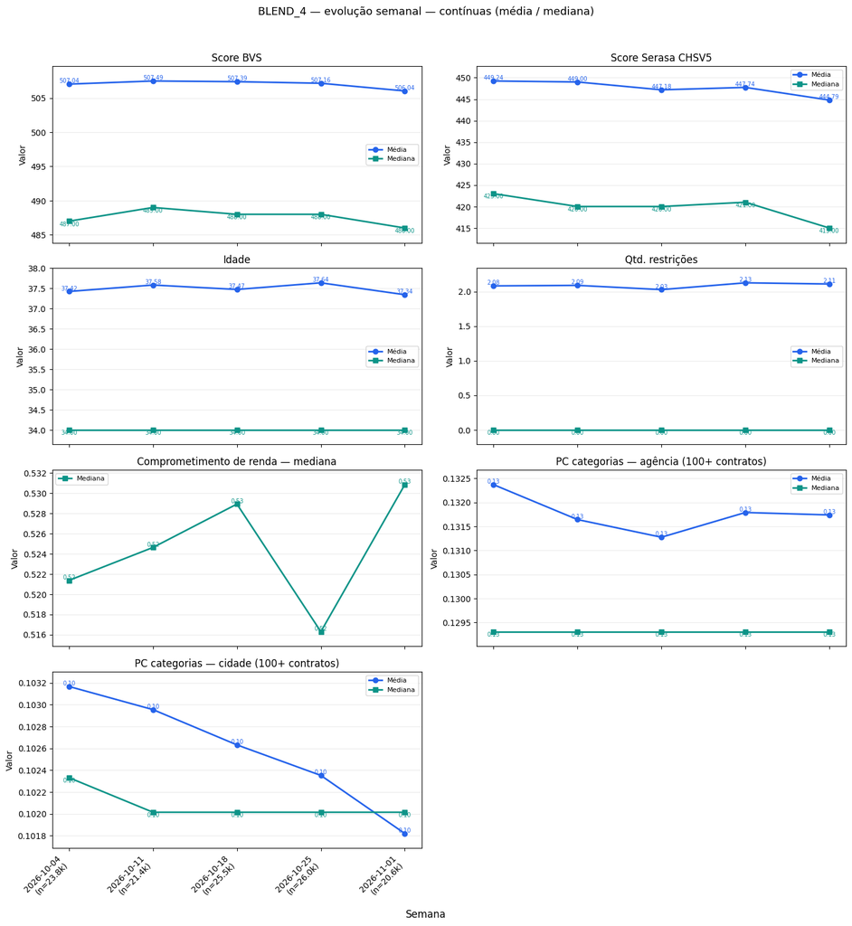

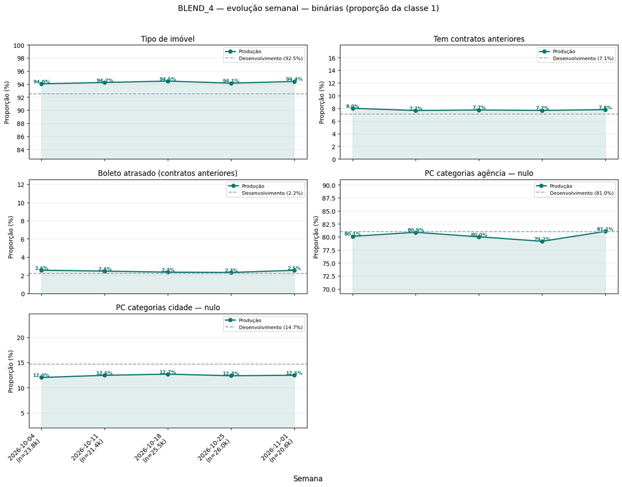

```
Contínuas — média
```

| year_week variable | 2026-10-04 | 2026-10-11 | 2026-10-18 | 2026-10-25 | 2026-11-01 |
| --- | --- | --- | --- | --- | --- |
| Score BVS | 507.038 | 507.494 | 507.392 | 507.160 | 506.037 |
| Score Serasa CHSV5 | 449.236 | 449.005 | 447.178 | 447.742 | 444.790 |
| Idade | 37.423 | 37.582 | 37.473 | 37.637 | 37.343 |
| Qtd. restrições | 2.083 | 2.090 | 2.029 | 2.127 | 2.110 |
| Comprometimento de renda | 0.698 | 16609.360 | 0.665 | 0.700 | 2129.593 |
| PC categorias — agência (100+ contratos) | 0.132 | 0.132 | 0.131 | 0.132 | 0.132 |
| PC categorias — cidade (100+ contratos) | 0.103 | 0.103 | 0.103 | 0.102 | 0.102 |

```
Contínuas — mediana
```

| year_week variable | 2026-10-04 | 2026-10-11 | 2026-10-18 | 2026-10-25 | 2026-11-01 |
| --- | --- | --- | --- | --- | --- |
| Score BVS | 487.000 | 489.000 | 488.000 | 488.000 | 486.000 |
| Score Serasa CHSV5 | 423.000 | 420.000 | 420.000 | 421.000 | 415.000 |
| Idade | 34.000 | 34.000 | 34.000 | 34.000 | 34.000 |
| Qtd. restrições | 0.000 | 0.000 | 0.000 | 0.000 | 0.000 |
| Comprometimento de renda | 0.521 | 0.525 | 0.529 | 0.516 | 0.531 |
| PC categorias — agência (100+ contratos) | 0.129 | 0.129 | 0.129 | 0.129 | 0.129 |
| PC categorias — cidade (100+ contratos) | 0.102 | 0.102 | 0.102 | 0.102 | 0.102 |

```
Binárias — proporção da classe 1 (%)
```

| year_week variable | 2026-10-04 | 2026-10-11 | 2026-10-18 | 2026-10-25 | 2026-11-01 |
| --- | --- | --- | --- | --- | --- |
| Tipo de imóvel | 94.0 | 94.2 | 94.5 | 94.1 | 94.4 |
| Tem contratos anteriores | 8.0 | 7.7 | 7.7 | 7.7 | 7.8 |
| Boleto atrasado (contratos anteriores) | 2.6 | 2.4 | 2.3 | 2.3 | 2.5 |
| PC categorias agência — nulo | 80.1 | 80.9 | 80.0 | 79.2 | 81.1 |
| PC categorias cidade — nulo | 12.0 | 12.5 | 12.7 | 12.4 | 12.5 |

# Negado Direto - BVS

Garantir que não estamos comprando SERASA para esse público

Esperado: 10-11% do público OOT reprova direto por BVS (Blend4).

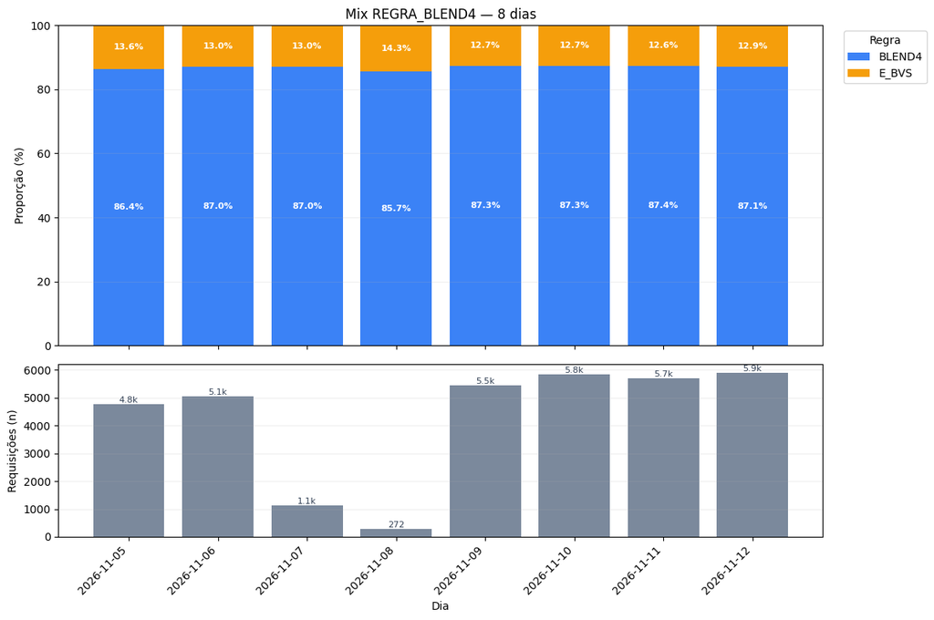

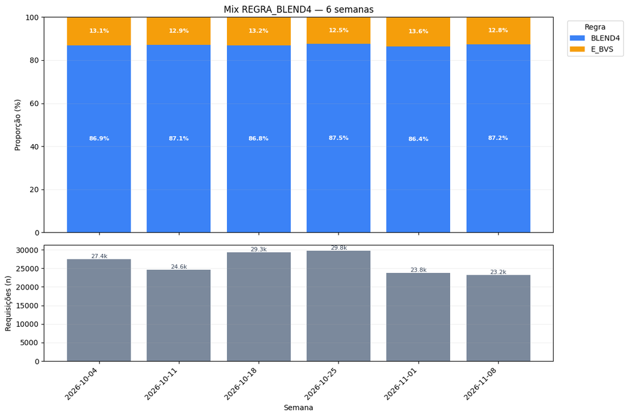

# Falhas (BVS, Serasa)

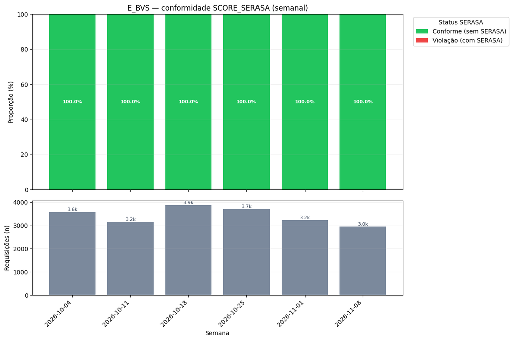

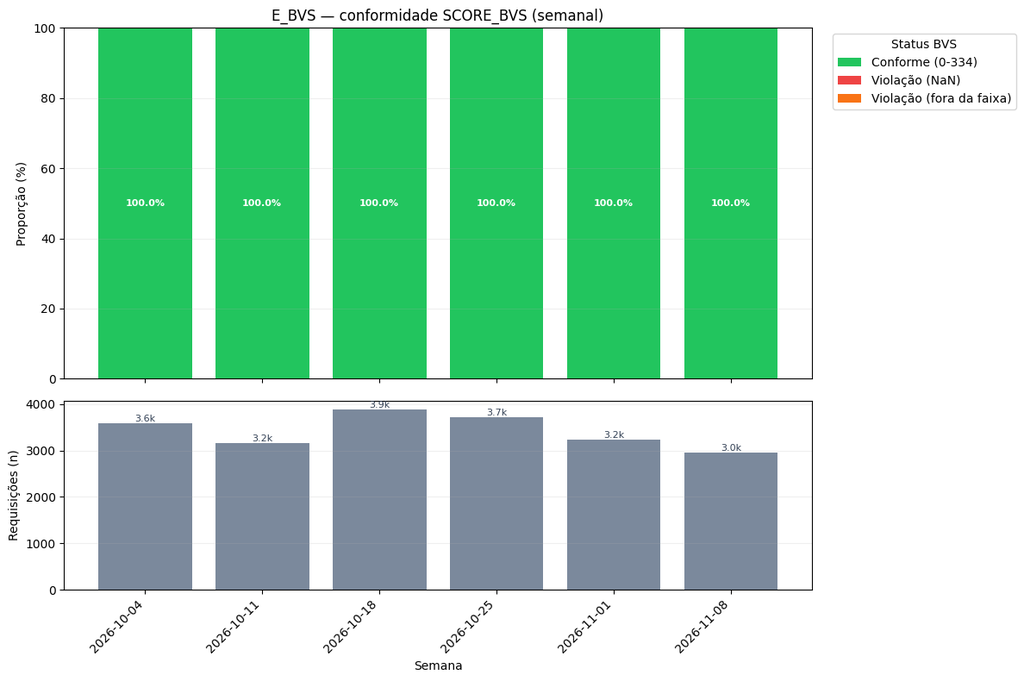

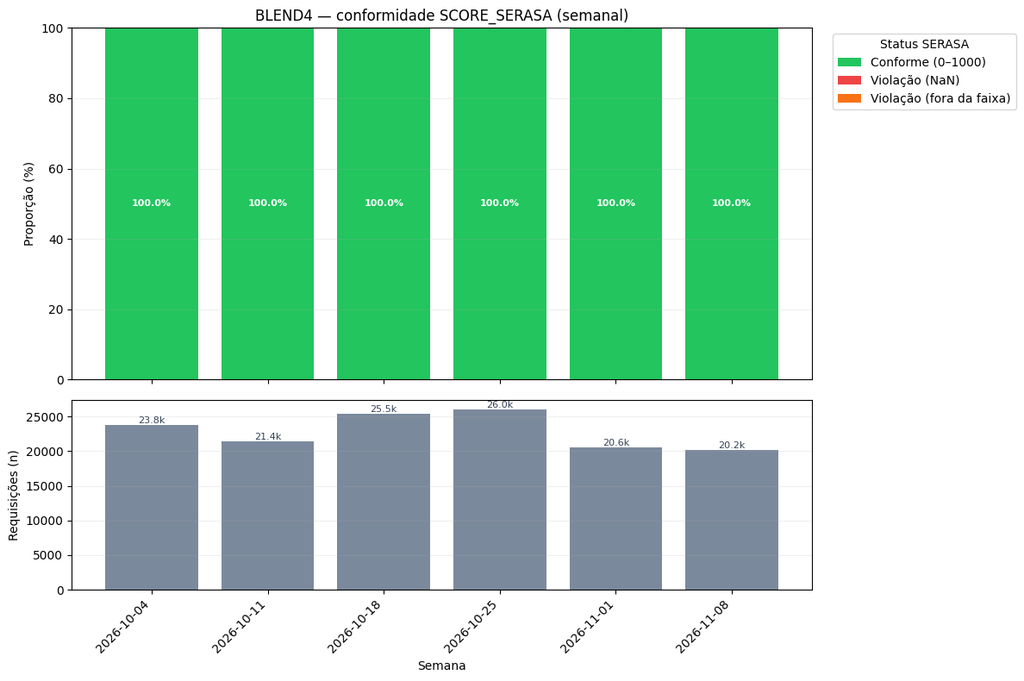

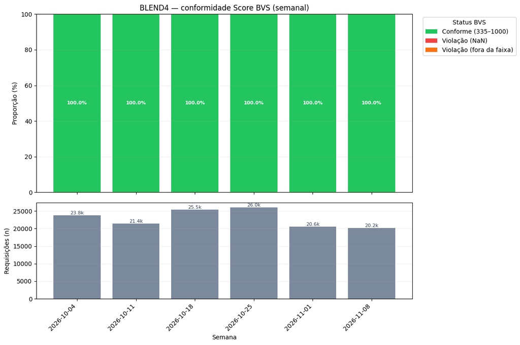

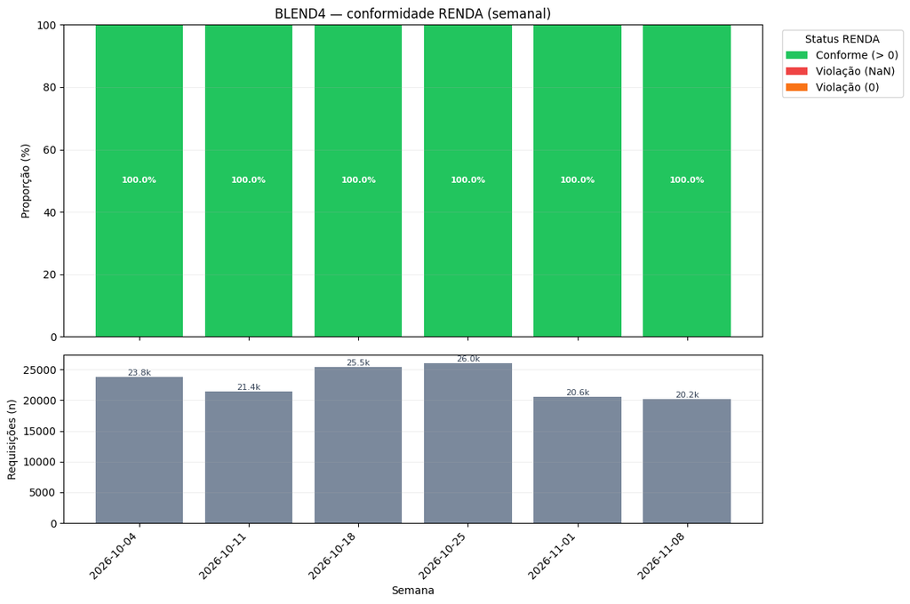